# Telemetry Data Analysis

## Proposal - CAP 394/2018

### Yuri Matheus Dias Pereira

### 31 August, 2018

# Satellite Operations

- Satellite Control Center - **CCS/INPE**
 - SCD1 & SCD2
 - CBERS
 - Amazônia

What about the data?
- **Besides** the payload
- Telemetry/Housekeeping for the operators
- Satellite -> Ground Station -> Satellite Control Center

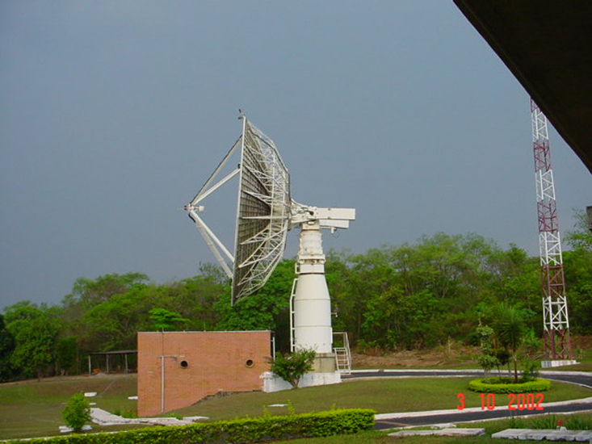

# Telemetry Data

- Satellites in general have hundreds or thousands of telemetries.
    - Hubble generated **3TB** of telemetries per year!<sup>1</sup>
- Useful only for operations and engineering.
- Mostly numerical, with some bit masks.
- Analysis is performed to see if the satellite will continue to perform its duties as it should.
- Engineering checks the values for subsystems health monitoring.
    - Important to know if the satellite will continue to work in the future
    - Or if it will exceed the expected lifetime

[1] Miebach, M. P. (may 1998). Hubble Space Telescope: Cost reduction by re-engineering telemetry processing and archiving.

# Telemetries Information

|  | ID | DESCRIPTION | EQP | SYSTEM | RANGE | ACCURACY |
| --- | --- | --- | --- | --- | --- | --- |
| 1 | TM001 | Receiver AGC voltage | DCP | DCS | -130 to -80 dBm | +/- 2 dB |
| 2 | TM002 | RF output power monitor | DCP | DCS | 17.5 to 20.5 dBm | +/- 0.2 dB |
| 3 | TM003 | Y axis output (300 mGauss) | MGE | ACS | -300 to 300 mG | +/- 2 mG |
| 4 | TM004 | -X axis output (300 mGauss) | MGE | ACS | -300 to 300 mG | +/- 2 mG |
| 5 | TM005 | Z axis output (300 mGauss) | MGE | ACS | -300 to 300 mG | +/- 2 mG |
| 6 | TM006 | Y axis output (600 mGauss) | MGE | ACS | -600 to 600 mG | +/- 5 mG |
| 7 | TM007 | -X axis output (600 mGauss) | MGE | ACS | -600 to 600 mG | +/- 5 mG |
| 8 | TM008 | Z axis output (600 mGauss) | MGE | ACS | -600 to 600 mG | +/- 5 mG |
| 9 | TM009 | Angie measurement bit 6 MSB | SS1 | ACS |  |  |
| 10 | TM010 | Angle measurement bit 5 | SS1 | ACS |  |  |

[output cut: 140 more lines]

# What I got.

- One satellite, hundreds of telemetries.
- Raw telemetries from `2014~2018` total about **~45GB** of **csv**
- Requires a database to work with everything on R...
- I'll focus on a single month of data (enough!)
    - `~345MB` of *csv* data
    - For R:

```r
format(object.size(telemetries), units = "auto", standard = "SI")
```

```
## [1] "231.6 MB"
```

```r
dim(telemetries)
```

```
## [1] 296909    135
```

# A look into the data

|  | date | TM001 | TM028 | TM026 |
| --- | --- | --- | --- | --- |
| 1 | 2018-03-01T11:14:40Z | -121.15 | NAO PROCESSADO | 1 |
| 2 | 2018-03-01T11:14:41Z | -121.92 | NAO PROCESSADO | 1 |
| 3 | 2018-03-01T11:14:41Z | -129.5 | NAO PROCESSADO | 1 |
| 4 | 2018-03-01T11:14:42Z | -120.38 | NAO PROCESSADO | 1 |
| 5 | 2018-03-01T11:14:42Z | -120.77 | NAO PROCESSADO | 1 |
| 6 | 2018-03-01T11:14:43Z | -123.85 | NAO PROCESSADO | 1 |
| 7 | 2018-03-01T11:14:43Z | -116.56 | NAO PROCESSADO | 1 |
| 8 | 2018-03-01T11:14:44Z | -121.15 | NAO PROCESSADO | 1 |
| 9 | 2018-03-01T11:14:44Z | -123.08 | NAO PROCESSADO | 1 |
| 10 | 2018-03-01T11:14:45Z | -127 | NAO PROCESSADO | 1 |

[output cut: 40 more lines]

# An image is worth a thousand words

[figure not shown]

```r
plotData(telemetries, telemetries.mge.600)
```

# What to do from here?

- Data Product
    - Anomaly Analysis -> Outlier Identification
    - Single variable
        - Cross recurrence quantification analysis
    - Multiple variables rule induction methods
        - Can unearth unseen patterns for engineering
    - Time Series modeling
        - Make stationary, try and see for trends
        - Also useful for outliers
        - ARIMA? SARIMA? Derivatives?

## For now...

- A combination of some ideas
    - *Data Imputation*
- How much useful data is lost in telecommunication?
- CRC Check

# CRC Idea

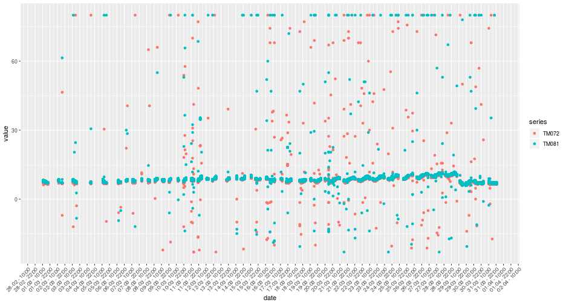

```r
plotData(telemetries, telemetries.pss.pcu.temp)
```

# Only valid data

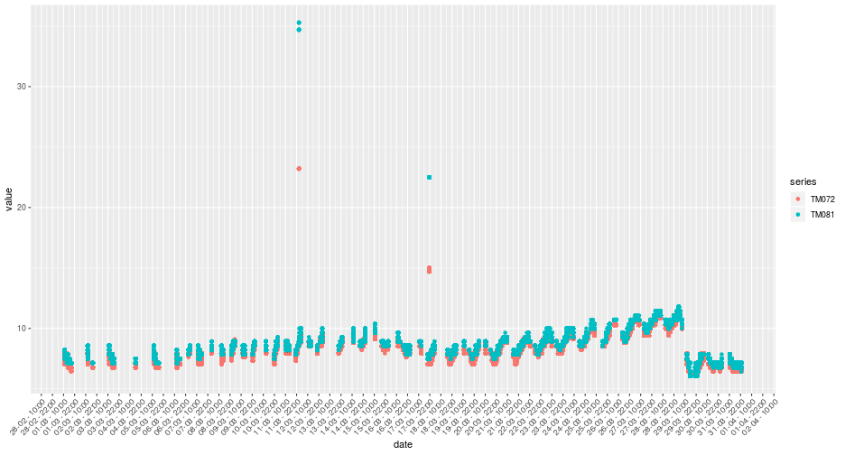

```r
plotData(telemetries.valid, telemetries.pss.pcu.temp)
```

# Only invalid data

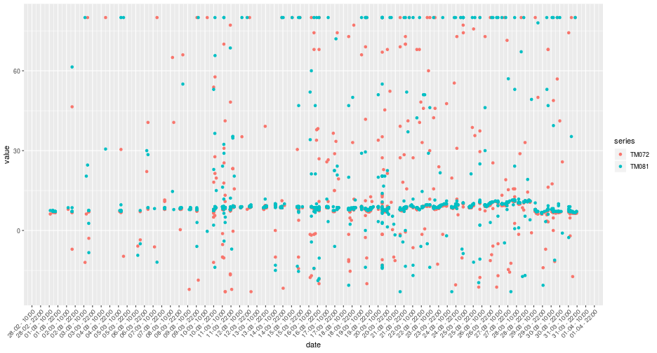

```r
plotData(telemetries.invalid, telemetries.pss.pcu.temp)
```

# Other ideas

- Data Science is essential for operations
    - So is artificial intelligence
- Less cost with operators:
    - Unfeasible to have one dedicated operator per satellite when you have *constellations*.
    - Sheer amount of future projects require some level of automation.
    - Other space operators have been doing it for *decades*.

## Problems

- Data *can't* be public
- Hard to get raw telemetry data
- Historic data is sometimes stashed away (tapes!)

# Thank you!

# Questions? Ideas?

# Extras

Slides created using Xaringan [**xaringan**](https://github.com/yihui/xaringan).